# Lab 8

2022-10-25

# Case Study: Acorn size and oak tree range (from Lab 7)

### Introduction

It is thought that the size of a plant’s seed may have some effect on the geographic range of a plant. In fact, a positive correlation is believed to exist between acorn size and the geographical range of the North American Oaks. The idea behind this theory is that larger acorns will be carried away by larger animals who in turn have a wider territorial range. Aizen and Patterson studied 39 species of oak trees to examine this correlation.

# Protocol

Fifty species of oaks are found growing in the United States, 80% of which are accounted for in the Atlantic and California regions. The 28 oaks in the Atlantic region and the 11 oaks in the California region were used in this study. Acorn size was expressed as a volume, using measurements of specific nut lengths and widths to estimate the acorn volume as the volume of an ellipsoid. The areas of the geographical range for each species were obtained from the available literature.

# Protocol (cont.)

The range of species number 11 of the California region is unusual in that it does not include any land on the continental United States.

This particular species of oak grows only on the Channel Islands of Southern Cax`lifornia (see the map) and the island of Guadalupe off the coast of Baja California. The area of the Channel Islands is 1014 sq. km and the area of the island of Guadalupe is 265 sq. km.

[figure not shown]

# Data

The data collected by Aizen & Patterson is provided in the file `acorn.txt`. The file `Readme_acorn.txt` describes what is in the data file.

# Question 1:

Look at the data file and the readme file and answer:

1. how many variables are present in the data file?
2. which ones are numerical? (name the subtype)
3. which ones are categorical (name the subtype)
4. how are the columns separated in the data file?

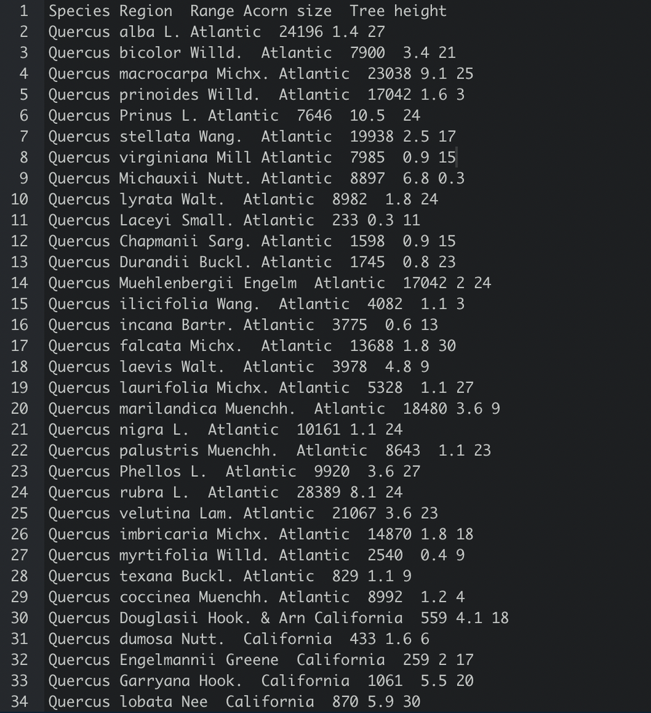

# Question 1 (answers):

Look at the data file and the readme file and answer:

# Question 1 (answers):

- how are the columns separated in the data file?

```r
#read.table("acorn.txt") #fails
?read.table
```

> “If sep =”” (the default for read.table) the separator is ‘white space’, that is one or more spaces, tabs, newlines or carriage returns.”

Let’s try tab!

```r
#read.table("acorn.txt") #fails
read.table("acorn.txt", sep="\t") #works!
#"\t" is tab in linux/programming world.
read.delim("acorn.txt") #also works.
#see ?read.delim. It's default is sep="\t"
readr::read_table("acorn.txt") #does not work; expects white space
```

# Question 2:

# Question 2 (answers):

- Read in the data file
- check its dimensions

```r
#Read in the data file
acorn<-read.delim("input_files/acorn.txt")
#check its dimensions
dim(acorn) #39 rows, 5 columns
```

```
## [1] 39  5
```

```r
nrow(acorn) #39
```

```
## [1] 39
```

```r
ncol(acorn) #5
```

```
## [1] 5
```

# Question 2 (answers):

- check its structure

```r
#check its structure
str(acorn)
```

```
## 'data.frame':    39 obs. of  5 variables:
##  $ Species    : chr  "Quercus alba L." "Quercus bicolor Willd." "Quercus macrocarpa Michx." "Quercus prinoides Willd." ...
##  $ Region     : chr  "Atlantic" "Atlantic" "Atlantic" "Atlantic" ...
##  $ Range      : int  24196 7900 23038 17042 7646 19938 7985 8897 8982 233 ...
##  $ Acorn.size : num  1.4 3.4 9.1 1.6 10.5 2.5 0.9 6.8 1.8 0.3 ...
##  $ Tree.height: num  27 21 25 3 24 17 15 0.3 24 11 ...
```

# Question 2 (answers):

- Do the classes of each column seem appropriate to you? Now is a good time to change them. *Species and Region could be better handled as factors (not ordered)*

```r
library(dplyr)
acorn <- acorn %>%
  mutate(Species=factor(Species), #transform to factor
         Region=factor(Region)) #transform to factor
```

# Question 2 (answers):

- check that there are no missing values.

```r
#check that there are no missing values.
# four ways. 1
summary(acorn) # no NAs show up in summaries
```

```
##                        Species          Region       Range
##  Quercus agrifolia Nee.    : 1   Atlantic  :28   Min.   :   13.0
##  Quercus alba L.           : 1   California:11   1st Qu.:  827.5
##  Quercus bicolor Willd.    : 1                   Median : 5328.0
##  Quercus Chapmanii Sarg.   : 1                   Mean   : 7882.6
##  Quercus chrysolepis Liebm.: 1                   3rd Qu.:11924.5
##  Quercus coccinea Muenchh. : 1                   Max.   :28389.0
##  (Other)                   :33
##    Acorn.size      Tree.height
##  Min.   : 0.300   Min.   : 0.30
##  1st Qu.: 1.100   1st Qu.:10.00
##  Median : 1.800   Median :18.00
##  Mean   : 3.341   Mean   :17.34
##  3rd Qu.: 4.450   3rd Qu.:24.00
##  Max.   :17.100   Max.   :30.00
##
```

# Question 2 (answers):

- check that there are no missing values.

```r
#2
table(is.na(acorn)) #195 FALSE
```

```
##
## FALSE
##   195
```

```r
#3
table(na.omit(acorn) == acorn) #if all are TRUE, there are no NAs
```

```
##
## TRUE
##  195
```

```r
#4
anyNA(acorn) #if FALSE, all good.
```

```
## [1] FALSE
```

# Question 3:

- What type of visualization would be appropriate in order to investigate the relationship between tree range and acorn size?
- Who are the response and explanatory variables here?
- Make that plot.

# Question 3 (answers):

- What type of visualization would be appropriate in order to investigate the relationship between tree range and acorn size? *Tree range is numerical and acorn size is also numerical. Therefore, a scatter plot.*
- Who are the response and explanatory variables here? *The idea is to investigate the idea that larger acorns get dispersed further by larger animals, so acorn size (explanatory) and range (response).*

# Question 3 (answers):

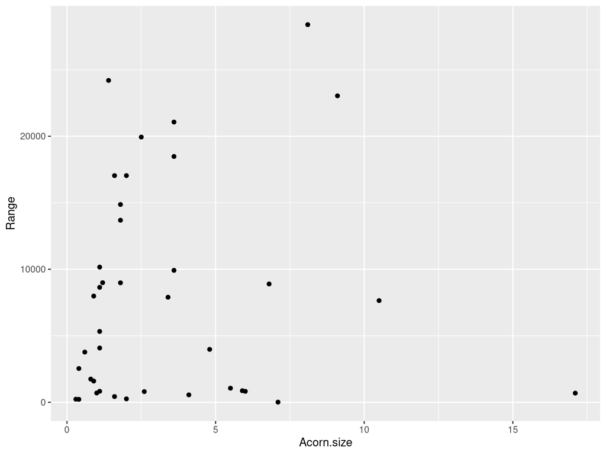

```r
library(ggplot2) #load ggplot package
ggplot(acorn, aes(x=Acorn.size, y=Range)) +  # basic scatter plot
  geom_point()
```

# Question 3 (answers):

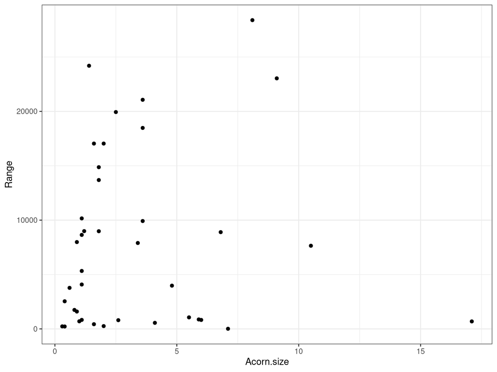

```r
library(ggplot2) #load ggplot package
ggplot(acorn, aes(x=Acorn.size, y=Range)) +
  geom_point() +
  theme_bw()  # white background
```

# Question 4:

Examine the summary statistics for tree range.

- What are the mean and the standard deviation?
- What do these values tell you about the likely shape of the distribution?

# Question 4 (answers):

Examine the summary statistics for tree range.

```r
mean(acorn$Range) #mean
```

```
## [1] 7882.564
```

```r
sd(acorn$Range) #standard deviation
```

```
## [1] 8054.823
```

```r
summary(acorn) # both and more
```

```
##                        Species          Region       Range
##  Quercus agrifolia Nee.    : 1   Atlantic  :28   Min.   :   13.0
##  Quercus alba L.           : 1   California:11   1st Qu.:  827.5
##  Quercus bicolor Willd.    : 1                   Median : 5328.0
##  Quercus Chapmanii Sarg.   : 1                   Mean   : 7882.6
##  Quercus chrysolepis Liebm.: 1                   3rd Qu.:11924.5
##  Quercus coccinea Muenchh. : 1                   Max.   :28389.0
##  (Other)                   :33
##    Acorn.size      Tree.height
##  Min.   : 0.300   Min.   : 0.30
##  1st Qu.: 1.100   1st Qu.:10.00
##  Median : 1.800   Median :18.00
##  Mean   : 3.341   Mean   :17.34
##  3rd Qu.: 4.450   3rd Qu.:24.00
##  Max.   :17.100   Max.   :30.00
##
```

# Question 4 (answers):

- Examine the summary statistics for tree range.

```r
library(dplyr)
acorn %>%
  summarise(mean(Range), sd(Range)) #produce two summaries at once
```

```
##   mean(Range) sd(Range)
## 1    7882.564  8054.823
```

```r
library(dplyr)
acorn %>%
  summarise(MeanRange=mean(Range), SDRange=sd(Range)) #name summaries
```

```
##   MeanRange  SDRange
## 1  7882.564 8054.823
```

# Question 4 (answers):

- Examine the summary statistics for tree range.

```r
library(dplyr)
acorn %>%
  select(Range) %>% #select col Range
  summary() #summary()
```

```
##      Range
##  Min.   :   13.0
##  1st Qu.:  827.5
##  Median : 5328.0
##  Mean   : 7882.6
##  3rd Qu.:11924.5
##  Max.   :28389.0
```

$$Median << Mean$$
$ * What do these values tell you about the likely shape of the distribution? *This suggests an enormous spread or range of the data. Also, 50% of the data are contained within 827 and 11924.5 and 75% of the data have values below 11924.5. Further, the median (5328) is much lower than the mean (7882.6), suggesting a strong right (positive) skew.*

```r
mean(acorn$Range)
```

```
## [1] 7882.564
```

# Question 4 (answers):

Distribution of Range:

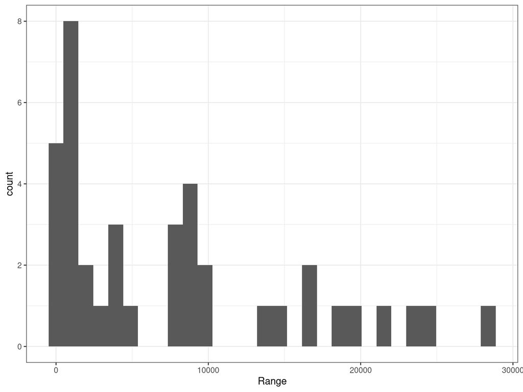

```r
#you could also plot the distribution to get this intuition.
# place the mean (7882.564) and median (5328) in this distribution
ggplot(acorn, aes(x=Range))  + geom_histogram() +
  theme_bw()
```

# Question 4 (answers):

Distribution of Acorn size:

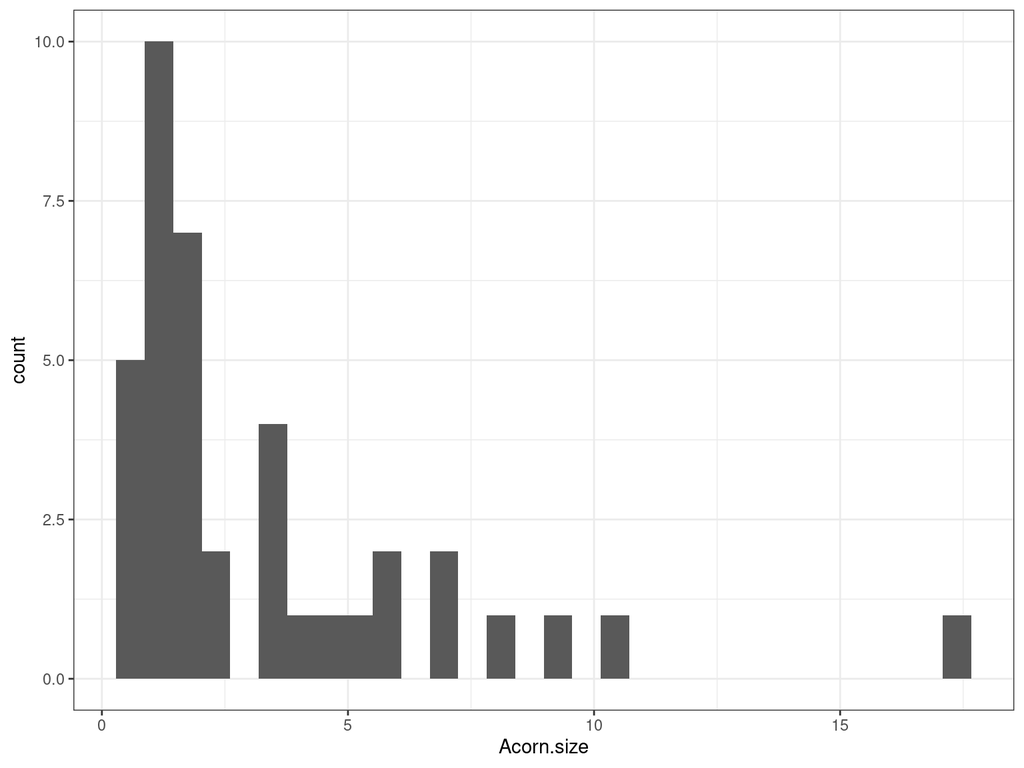

```r
#you could also plot the distribution to get this intuition.
# place the mean mean and median in this distribution
ggplot(acorn, aes(x=Acorn.size))  + geom_histogram() +
  theme_bw()
```

# Question 5:

- Transform the data using the log transformation on both the range and the size.

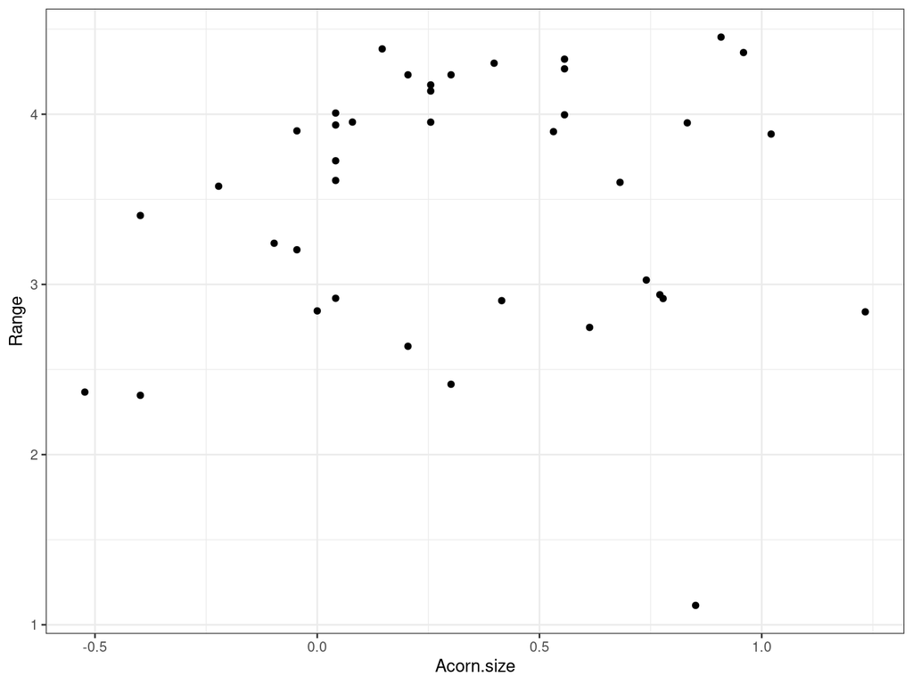

```r
#transform to log scale. Option 1
acorn2<- acorn %>%
  mutate(Range=log(Range, base=10), #log10 would also work
            Acorn.size=log(Acorn.size, base=10))

ggplot(acorn2, aes(x=Acorn.size, y=Range)) +
  geom_point() +
  theme_bw()  # white background
```

# Question 5:

- Transform the data using the log transformation on both the range and the size.

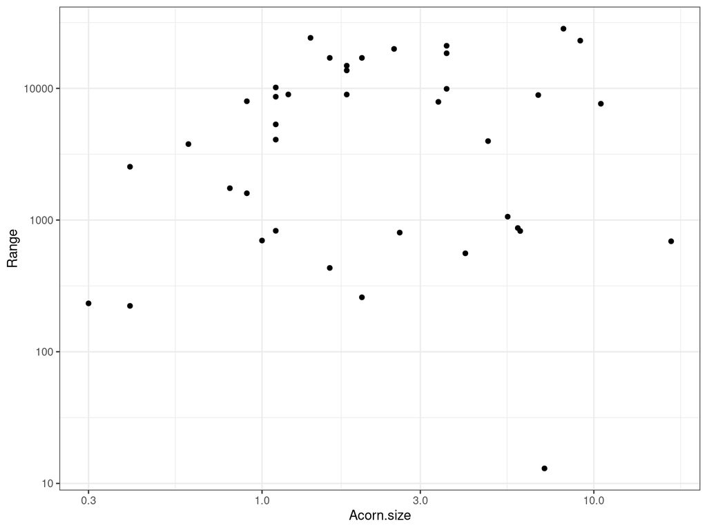

```r
# ggplot2 directly option 2
ggplot(acorn, aes(x=Acorn.size, y=Range)) +
  geom_point() +
  scale_y_continuous(trans="log10") +
  scale_x_continuous(trans="log10") +
  theme_bw()  # white background
```

# Question 5:

- Transform the data using the log transformation on both the range and the size.

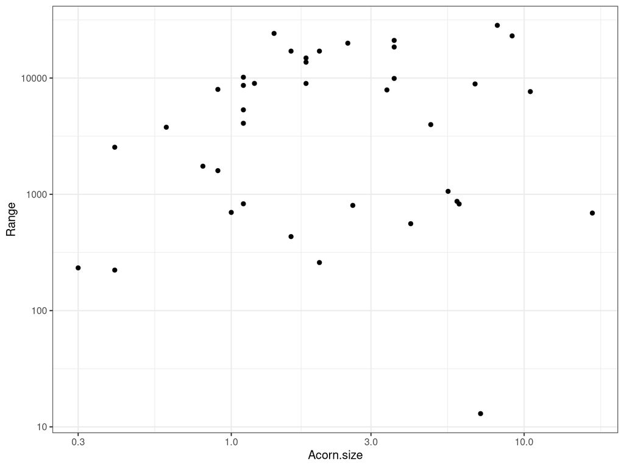

```r
# ggplot2 directly option 3
ggplot(acorn, aes(x=Acorn.size, y=Range)) +
  geom_point() +
  scale_x_log10() +
  scale_y_log10() +
  theme_bw()  # white background
```

# Question 5:

- Now make a scatter plot of Ln(range) vs. Ln(acorn size).

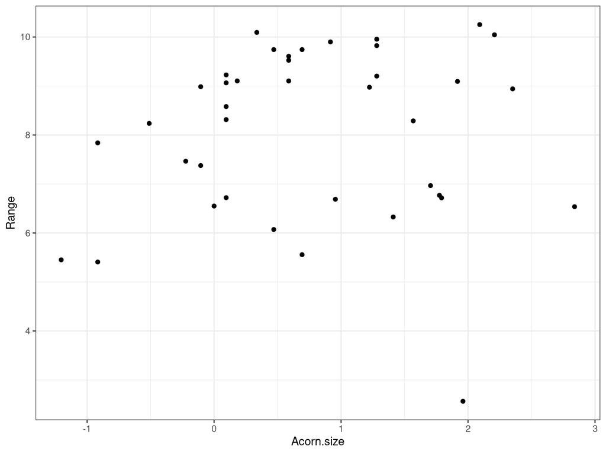

```r
#option 1
acorn3<- acorn %>%
  mutate(Range=log(Range), #default base is e (2.718281828459)
            Acorn.size=log(Acorn.size))

ggplot(acorn3, aes(x=Acorn.size, y=Range)) +
  geom_point() +
  theme_bw()
```

# Question 5:

- Now make a scatter plot of Ln(range) vs. Ln(acorn size).

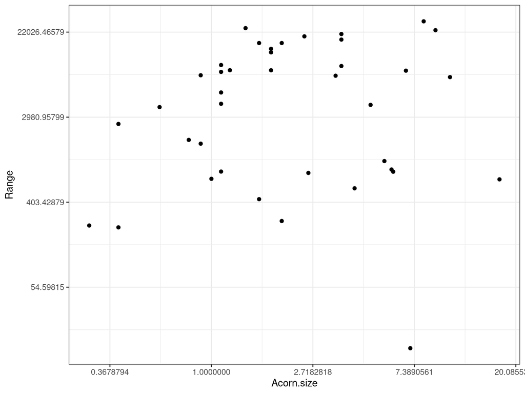

```r
#option 2
ggplot(acorn, aes(x=Acorn.size, y=Range)) +
  geom_point() +
  scale_y_continuous(trans="log") +
  scale_x_continuous(trans="log") +
  theme_bw()  # white background
```

# Question 5:

- How did the pattern change? Does it surprise you? Do you see any obvious reason that might help explain the correlation?

*ince both distributions have a longer than normal right-tail, a log transformation might be suggested to dampen the influence of the largest observations. Also, relationships between the transformed variables would then be interpretable on a relative scale. It now becomes apparent there is a positive relationship between the two.*

# Question 6:

Compare boxplots of tree range by geographical region in order to investigate the relationship between tree range and region. What do you learn?

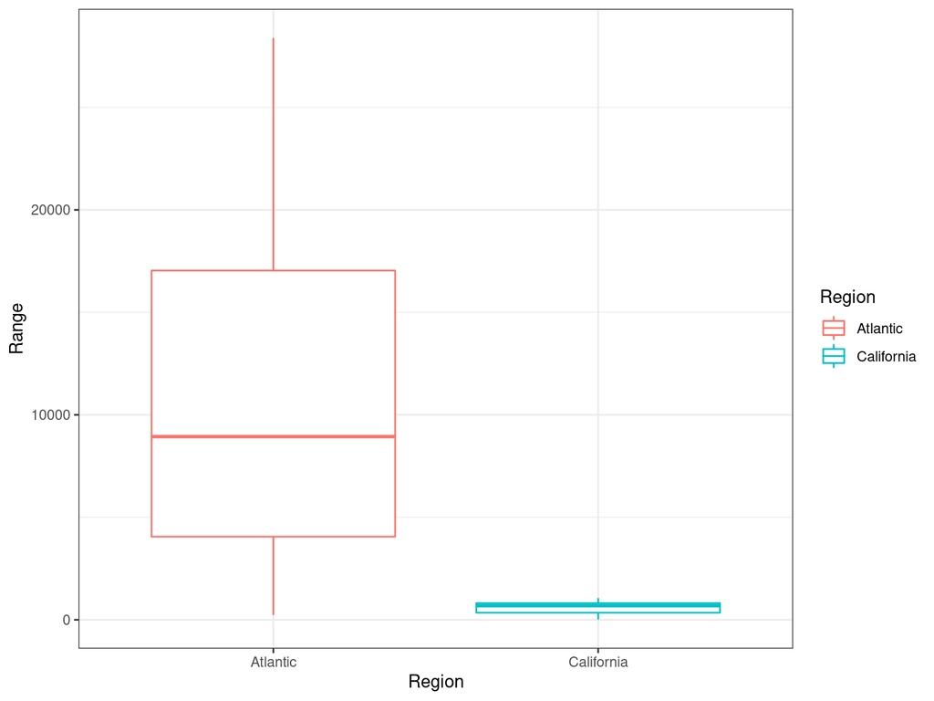

```r
#boxplot of Range by Region
ggplot(acorn, aes(x=Region, y=Range, color=Region)) +
  geom_boxplot() +
  theme_bw() #white background
```

*The comparative boxplots show that the bigger ranges are found in the Atlantic region, the smaller ranges are found in the California region.*

# Question 7:

- Make an appropriate plot of Ln(range) vs. Ln(acorn size) for the Atlantic region. Is the correlation (visually) any better than that found in Question 1? *You didn’t really have to calculate the correlation but just visually assess it. The scatter plot for the Atlantic Region shows a moderate positive association.*

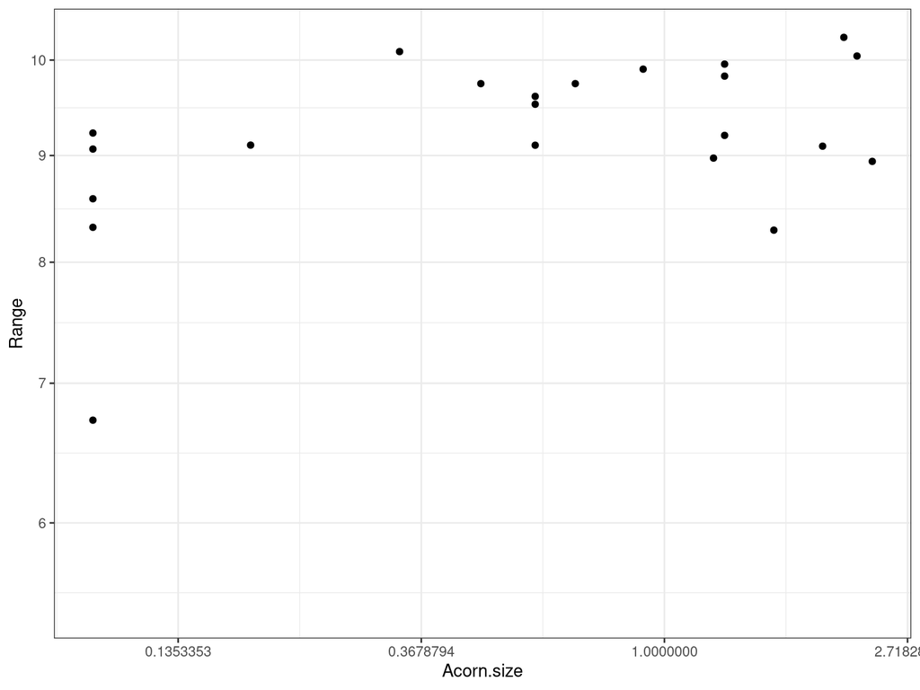

```r
#Atlantic
acorn3 %>%
  filter(Region=="Atlantic") %>% #atlantic region
  ggplot(aes(x=Acorn.size, y=Range)) + #does not require input because of %>%
  geom_point() +
  scale_y_continuous(trans="log") + #log transformation
  scale_x_continuous(trans="log") +
  theme_bw()  # white background
```

# Question 7:

- Make an appropriate plot of Ln(range) vs. Ln(acorn size) for the California region. What is the correlation? Why do you think that the correlation is so low? *You didn’t really have to calculate the correlation but just visually assess it. It seems pretty low here.This low correlation is due to the presence of the outlier at the bottom right of the plot. The rest of the data seem to be associated in a stronger manner.*

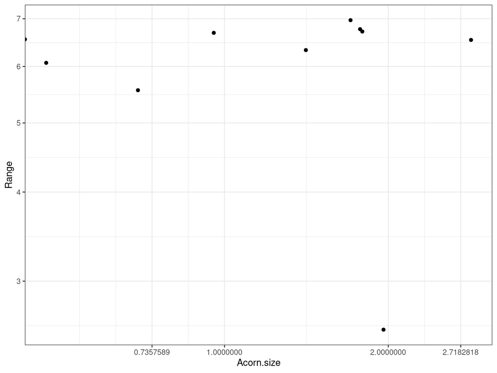

```r
#California
acorn3 %>%
  filter(Region =="California") %>% #atlantic region
  ggplot(aes(x=Acorn.size, y=Range)) + #does not require input because of %>%
  geom_point() +
  scale_y_continuous(trans="log") + #log transformation
  scale_x_continuous(trans="log") +
  theme_bw()  # white background
```

# Question 7:

Convince yourself of this by adding a linear regression line for both plots:

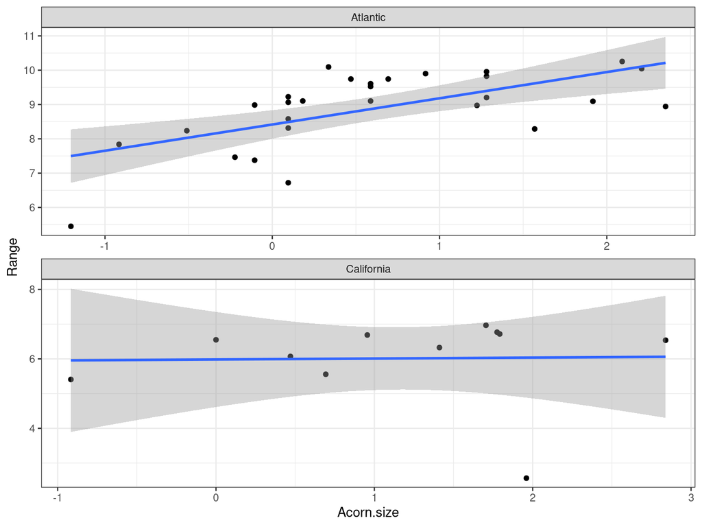

```r
#scatter plots by Region with regression line
acorn3 %>%
  ggplot(aes(x=Acorn.size, y=Range)) + #does not require input because of %>%
  geom_point() +
  stat_smooth(method="lm")+
  theme_bw() +  # white background
  facet_wrap(vars(Region),nrow = 2,scales="free") #splits plots by column Region
```

# Exercise 2: Taking your first function to the next level!

In Lab 6, you created a simple function that takes in a user defined value and converts into something else. Specifically, the function convert a temperature in Celsius to the corresponding temperature in Fahrenheit. You were then asked to make a similar function that converts temperature in Fahrenheit to Celsius. If you didn’t complete that activity, you should do so before moving forward. This is under Lab6_Activity in Rstudio Cloud but also posted on Moodle.

You had two tasks:

1. Combine both functions into one. Basically, you want the function to have two arguments: temperature in Celsius and temperature in Fahrenheit. A few things to consider:
- only one of the two arguments should be provided by the user
- how does the function decide what to do based on the user input?
- what happens if the user does not understand the function and provides both arguments?
2. Apply your function to the “Temp” column to the `airquality` dataset from the `datasets` package.

# Task 1: Combine both functions into one.

```r
#function to convert Fahrenheit to Celsius
FtoC<-function(tf){ #one argument:tf
tc<-(tf-32)/1.8 #conversion F to C
return(tc) #output of the function
}
```

```r
#function to convert Fahrenheit to Celsius
CtoF<-function(tc){ #one argument:tf
tf<-(tc * 1.8) + 32 #conversion C to F
return(tf) #output of the function
}
```

Test

```r
FtoC(tf=104)
```

```
## [1] 40
```

```r
CtoF(tc=40)
```

```
## [1] 104
```

# Conditional statements

Example:

```r
if (TRUE){
  print ("This will execute...")
} else
{
  print ("but this will not.")
}
```

```
## [1] "This will execute..."
```

# Task 1: Combine both functions into one.

Setting the stage: (this is not real code)

```r
temp_conv<-function(parameters){ #define function and parameters
  if(temp is in Celsius){
    conver to fahrenheit
  } else { #othersise
    convert fahrenheit to celsius

  }
```

# Task 1: Combine both functions into one.

Real code:

```r
temp_conv<-function(t=30, unit="C"){ #define function and parameters
  if(unit=="C"){
    t2<-(t * 1.8) + 32 #converto to Fahrenheit
  } else { #otherwise
    t2<-(t-32)/1.8 #convert to Celsius
  }
  return(t2)
}
#tests
temp_conv(t=45, unit="C")
temp_conv(t=45, unit="F")
temp_conv(t=110, unit="F")
temp_conv(t=110, unit="C")
```

[output not shown]